# 1.DeepWalk Node Embedding

```python
import pandas as pd
import numpy as np
import matplotlib.pyplot as plt

import warnings
warnings.filterwarnings("ignore")
```

## 1. DeepWalk Movie Embeddings

### read data from csv

```python
ratings = pd.read_excel('ratings.xlsx')
users = pd.read_excel('users.xlsx')
movies = pd.read_excel('movies.xlsx')

ratings = ratings.drop(['Unnamed: 1','Unnamed: 3','Unnamed: 5'],axis = 1)
users = users.drop(['Unnamed: 1','Unnamed: 3','Unnamed: 5','Unnamed: 7'],axis = 1)

movies = movies.fillna('')
movies['Title'] = movies['Toy Story (1995)'].map(str)+ movies['Unnamed: 3'].map(str)
movies['Genres'] = movies.iloc[:,4].map(str)+ movies.iloc[:,5].map(str) +movies.iloc[:,6].map(str)

movies = movies.rename(columns = {1:'MovieID'})
movies = movies[['MovieID','Title','Genres']]

ratings.columns = ['UserID','MovieID','Rating','Timestamp']
users.columns = ['UserID','Gender','Age','Occupation','Zip_code']
```

#### transform adjcent list

The adjcent list is created by collection of unordered movie lists that each UserID has rated. They represent a finite movie-interaction graph.

Each list describes the set of neighbors (movies that share common features in some degrees) of a vertex (movie) in the graph (network) based on users' behaviors.

```python
subset = ratings[['UserID', 'MovieID']]
temp1 = subset.groupby('UserID').MovieID.apply(lambda x: sorted(x.values))
temp1.head()
```

```
UserID
1    [1, 48, 150, 260, 527, 531, 588, 594, 595, 608...
2    [21, 95, 110, 163, 165, 235, 265, 292, 318, 34...
3    [104, 260, 480, 552, 590, 593, 648, 653, 733, ...
4    [260, 480, 1036, 1097, 1196, 1198, 1201, 1210,...
5    [6, 16, 24, 29, 32, 34, 36, 39, 41, 47, 50, 52...
Name: MovieID, dtype: object
```

```python
temp1.to_csv('M.adjlist',index=False)
```

For example, UserID 1 has rated for numbers of 52 movies, MovieID of {2687, 1022, 48, 1197 ... , 3071}

#### Data Exploration

```python
ratings.shape
```

```
(1000208, 4)
```

```python
movies.shape
```

```
(3882, 3)
```

```python
temp = subset.groupby('UserID').MovieID.apply(lambda x: x.value_counts())
temp.head()
```

```
UserID
1       2687    1
        1022    1
        48      1
        1197    1
        1836    1
Name: MovieID, dtype: int64
```

```python
ratings_unstack = temp.unstack().fillna(0)
ratings_unstack.tail()
```

| UserID | 1 | 2 | 3 | 4 | 5 | 6 | 7 | 8 | 9 | 10 | ... | 3943 | 3944 | 3945 | 3946 | 3947 | 3948 | 3949 | 3950 | 3951 | 3952 |
| --- | --- | --- | --- | --- | --- | --- | --- | --- | --- | --- | --- | --- | --- | --- | --- | --- | --- | --- | --- | --- | --- |
| 6036 | 0.0 | 0.0 | 0.0 | 1.0 | 0.0 | 1.0 | 0.0 | 0.0 | 0.0 | 0.0 | ... | 0.0 | 0.0 | 0.0 | 0.0 | 0.0 | 0.0 | 0.0 | 0.0 | 0.0 | 0.0 |
| 6037 | 0.0 | 0.0 | 0.0 | 0.0 | 0.0 | 0.0 | 0.0 | 0.0 | 0.0 | 0.0 | ... | 0.0 | 0.0 | 0.0 | 0.0 | 0.0 | 0.0 | 0.0 | 0.0 | 0.0 | 0.0 |
| 6038 | 0.0 | 0.0 | 0.0 | 0.0 | 0.0 | 0.0 | 0.0 | 0.0 | 0.0 | 0.0 | ... | 0.0 | 0.0 | 0.0 | 0.0 | 0.0 | 0.0 | 0.0 | 0.0 | 0.0 | 0.0 |
| 6039 | 0.0 | 0.0 | 0.0 | 0.0 | 0.0 | 0.0 | 0.0 | 0.0 | 0.0 | 0.0 | ... | 0.0 | 0.0 | 0.0 | 0.0 | 0.0 | 0.0 | 0.0 | 0.0 | 0.0 | 0.0 |
| 6040 | 1.0 | 0.0 | 0.0 | 0.0 | 0.0 | 0.0 | 0.0 | 0.0 | 0.0 | 0.0 | ... | 0.0 | 0.0 | 0.0 | 0.0 | 0.0 | 0.0 | 0.0 | 0.0 | 0.0 | 0.0 |

5 rows × 3706 columns

```python
ratings_unstack.shape
```

```
(6040, 3706)
```

1,000,208 rating records of movies from users.

3,882 movies (MovieID: 2 .... 3952, missing some IDs)

We have 6040 users that rate movies.

3706 movies has been rated and 176 movies has not been rated.

```python
user_activation = ratings_unstack.sum(axis = 1)
movie_popularity = ratings_unstack.mean(axis = 0)
```

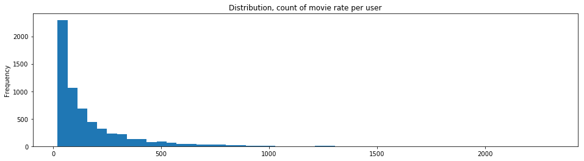

```python
user_activation.plot(kind = 'hist',bins = 50,figsize = (16,4),title = 'Distribution, count of movie rate per user')
plt.show()
```

we should remove users who has viewed too many movies in the embedding stage because of suspection of pranks. Avoid adding low quality edges into the graph.

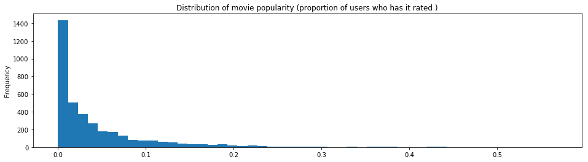

```python
movie_popularity.plot(kind = 'hist',bins = 50,figsize = (16,4),title = 'Distribution of movie popularity (proportion of users who has it rated )')
plt.show()
```

In first round of embedding experiment, we exclude movies that are extremely popular to aviod too much connection between popular movies in the graph since we want to recommend "right" and "personalize" movies to users intead of the popular ones. However, after learning the DeepWalk method, those connections are important for random walks to discover other potential links between movies, so we will include all the movies in this round.

#### remove highly active users

```python
ratings_unstack = ratings_unstack[user_activation < 500]
ratings_unstack.shape
```

```
(5641, 3706)
```

```python
adjlist.shape
```

[output not shown]

##### adjcent list is reduced

(user who rate movies , movies that are rated): (6040,3706) => (5641, 3706)

We have 5641 users that rate movies.

3706 movies has been rated, which means we will have 3706 vertices in the graph. Vertices are connected by edges based on these 5641 users' movie taste (user behaviour).

##### format adj list

```python
adj_l = []
for col in ratings_unstack.columns:
    sub = ratings_unstack[ratings_unstack[col] == 1]
    sub = sub.drop(col,axis = 1)
    neibours = sub.columns[sub.sum(axis = 0) != 0]
    neibours_str = ' '.join(neibours.map(str))
    adj_row = str(col)+' '+neibours_str
    adj_l.append(adj_row)
```

```python
adjlist = pd.Series(adj_l)
adjlist.to_csv('movies.adjlist',index=False)
```

```python
len(list(adjlist[5]))
```

```
15448
```

```python
adjlist.shape #3706 vertices in movie-interaction graph
```

```
(3706,)
```

#### Read Deepwalk Embeddings

DeepWalk github: https://github.com/phanein/deepwalk

#### $deepwalk helps

usage: deepwalk [-h] [--debug] [--format FORMAT] --input [INPUT] [-l LOG] [--matfile-variable-name MATFILE_VARIABLE_NAME] [--max-memory-data-size MAX_MEMORY_DATA_SIZE] [--number-walks NUMBER_WALKS] --output OUTPUT [--representation-size REPRESENTATION_SIZE] [--seed SEED] [--undirected UNDIRECTED] [--vertex-freq-degree] [--walk-length WALK_LENGTH] [--window-size WINDOW_SIZE] [--workers WORKERS]

#### First Round (Default) Parameter Setting w/ Steps

```python
embeddings = pd.read_csv('movie.embeddings',delimiter=' ',header = None, skiprows=[0])
embeddings = embeddings.rename(columns = {0: 'MovieID'})
embeddings.columns = ['embedded_'+str(i) for i in embeddings.columns]
#embeddings = embeddings.set_index('MovieID')
embeddings.shape
```

```
(3706, 65)
```

```python
embeddings = embeddings.rename(columns = {'embedded_MovieID':'MovieID'})
embeddings.head()
```

|  | MovieID | embedded_1 | embedded_2 | embedded_3 | embedded_4 | embedded_5 | embedded_6 | embedded_7 | embedded_8 | embedded_9 | ... | embedded_55 | embedded_56 | embedded_57 | embedded_58 | embedded_59 | embedded_60 | embedded_61 | embedded_62 | embedded_63 | embedded_64 |
| --- | --- | --- | --- | --- | --- | --- | --- | --- | --- | --- | --- | --- | --- | --- | --- | --- | --- | --- | --- | --- | --- |
| 0 | 593 | -0.001839 | -0.208218 | -0.149449 | -0.275163 | -0.021372 | -0.262893 | -0.119091 | 0.230677 | -0.004118 | ... | -0.314555 | -0.007452 | -0.000687 | 0.307971 | -0.117052 | -0.159724 | -0.188805 | 0.070386 | -0.113475 | 0.106010 |
| 1 | 110 | 0.028882 | -0.134147 | 0.074782 | 0.057043 | 0.022140 | -0.106065 | 0.060798 | 0.388916 | -0.233957 | ... | -0.124475 | 0.071543 | 0.144474 | 0.100835 | -0.150544 | -0.107531 | 0.026665 | 0.044447 | 0.044340 | -0.030112 |
| 2 | 2997 | -0.029225 | -0.079466 | -0.116360 | 0.006065 | 0.011736 | -0.155851 | -0.179037 | 0.304760 | 0.065357 | ... | -0.319918 | -0.190454 | 0.003364 | 0.424806 | 0.235658 | 0.102223 | -0.007764 | 0.107270 | 0.235967 | 0.211791 |
| 3 | 356 | -0.022119 | 0.052959 | 0.029533 | -0.050222 | -0.023208 | -0.017691 | 0.122533 | 0.333582 | 0.000737 | ... | -0.230502 | 0.030883 | -0.328825 | 0.156806 | -0.205822 | -0.007843 | 0.009679 | -0.028170 | 0.096924 | 0.342837 |
| 4 | 3471 | 0.033819 | -0.051301 | 0.009521 | 0.151771 | -0.018335 | 0.066269 | 0.100171 | 0.200708 | 0.198458 | ... | 0.065570 | 0.024125 | -0.032210 | 0.155578 | -0.046176 | 0.185949 | -0.048518 | 0.227705 | 0.217821 | -0.040662 |

5 rows × 65 columns

DeepWalk maps 3706 movies into 3706 low-dim vertex representations (dim of 64)

### Combine Embeddings w/ Other Features

```python
movie_features = (ratings.merge(movies,left_on= 'MovieID',right_on = 'MovieID',how = 'left')
                 .merge(users,left_on= 'UserID',right_on = 'UserID',how = 'left'))
```

```python
movie_features.fillna(0.0,inplace = True)
```

```python
#movie_features = movie_features.drop('Title',axis = 1)
#movie_features = movie_features.drop('Zip_code',axis = 1)
#movie_features = movie_features.drop('Timestamp',axis = 1)
```

```python
#movie_features.to_csv('feature_set_rating.csv') #for node2vec to draw graph
```

```python
import pandas as pd
import numpy as np
full_set = pd.read_csv('feature_set_rating.csv')
full_set.tail()
```

|  | UserID | MovieID | Rating | Genres | Gender | Age | Occupation |
| --- | --- | --- | --- | --- | --- | --- | --- |
| 1000203 | 6040 | 1091 | 1 | Comedy | M | 25 | 6 |
| 1000204 | 6040 | 1094 | 5 | Drama\|Romance\|War | M | 25 | 6 |
| 1000205 | 6040 | 562 | 5 | Comedy\|Drama | M | 25 | 6 |
| 1000206 | 6040 | 1096 | 4 | Drama | M | 25 | 6 |
| 1000207 | 6040 | 1097 | 4 | Children's\|Drama\|Fantasy\|Sci-Fi | M | 25 | 6 |

```python
full_set = movie_features.merge(embeddings,left_on = 'MovieID',right_on = 'MovieID',how = 'left')
```

```python
full_set.to_csv('feature_set.csv',index = False)
```

#### load feature_set_rating and split into train and test set CSV for DeepFM

```python
import pandas as pd
import numpy as np
full_set = pd.read_csv('feature_set.csv')
```

```python
full_set.shape
```

```
(1000208, 73)
```

```python
full_set = full_set.drop('Zip_code',axis = 1)
full_set.tail()
```

|  | UserID | MovieID | Rating | Genres | Gender | Age | Occupation | embedded_1 | embedded_2 | embedded_3 | ... | embedded_55 | embedded_56 | embedded_57 | embedded_58 | embedded_59 | embedded_60 | embedded_61 | embedded_62 | embedded_63 | embedded_64 |
| --- | --- | --- | --- | --- | --- | --- | --- | --- | --- | --- | --- | --- | --- | --- | --- | --- | --- | --- | --- | --- | --- |
| 1000203 | 6040 | 1091 | 1 | Comedy | M | 25.0 | 6.0 | -0.092902 | 0.056900 | 0.011286 | ... | 0.090825 | 0.064194 | 0.068213 | 0.136444 | -0.070385 | 0.059299 | -0.325212 | -0.073934 | 0.448873 | 0.279851 |
| 1000204 | 6040 | 1094 | 5 | Drama\|Romance\|War | M | 25.0 | 6.0 | -0.095246 | -0.167268 | 0.120715 | ... | 0.006156 | 0.159009 | -0.142423 | 0.122671 | -0.152327 | 0.184185 | -0.066246 | -0.072844 | -0.013102 | 0.365621 |
| 1000205 | 6040 | 562 | 5 | Comedy\|Drama | M | 25.0 | 6.0 | 0.031244 | -0.122108 | -0.208762 | ... | -0.255255 | 0.088500 | -0.004684 | 0.123492 | 0.045527 | -0.073459 | -0.455555 | 0.071138 | 0.153842 | 0.154384 |
| 1000206 | 6040 | 1096 | 4 | Drama | M | 25.0 | 6.0 | -0.075538 | 0.019253 | -0.082550 | ... | 0.068472 | 0.100736 | 0.065244 | 0.118917 | -0.202090 | 0.162722 | -0.149074 | 0.088829 | 0.216150 | 0.322566 |
| 1000207 | 6040 | 1097 | 4 | Children's\|Drama\|Fantasy\|Sci-Fi | M | 25.0 | 6.0 | 0.091530 | -0.043612 | 0.164355 | ... | -0.053948 | -0.229037 | 0.091952 | 0.242493 | -0.033328 | 0.172296 | -0.066699 | -0.036151 | -0.055713 | 0.136897 |

5 rows × 71 columns

```python
fullset = full_set.drop(['UserID','MovieID'],axis = 1)
```

```python
from sklearn.model_selection import train_test_split

fullset = fullset.reset_index()

fullset.rename(columns = {'Rating': 'target'},inplace = True)

fullset = fullset.apply(np.random.permutation)

X_train, X_test, y_train, y_test = train_test_split(fullset.drop('target',axis = 1),fullset.target, test_size = 0.333)

X_train['target'] = y_train
X_test['target'] = y_test

X_train.to_csv('trainW.csv')
X_test.to_csv('testW.csv')
```

```python
y_train.shape
```

```
(667138,)
```

```python
y_test.shape
```

```
(333070,)
```

667138 observations in train set and 333070 observations in test set

```python
fullset.shape
```

[output not shown]